# Activity 1.3: SNP Calling using Assembled Genomes

Laura M. Carroll

4/21/2019

# 1 Introduction

**Goal:** Identify single nucleotide polymorphisms (SNPs) in assembled bacterial genomes

**Input:** Assembled genomes in fasta format (*.fasta)

**Output:** SNPs in fasta format (*.fasta); phylogenies in Newick format

**Programs Used:**

- [kSNP3](https://sourceforge.net/projects/ksnp/): a reference-free SNP calling pipeline
- [FigTree](https://github.com/rambaut/figtree/releases): software for viewing and annotating phylogenies
- [SISTR](https://lfz.corefacility.ca/sistr-app/): *in silico* serotyping of *Salmonella* genomes
- [Parsnp](https://harvest.readthedocs.io/en/latest/content/parsnp.html): a reference-based core SNP calling pipeline
- [HarvestTools](https://harvest.readthedocs.io/en/latest/content/harvest-tools.html): toolkit for manipulating Gingr files (*.ggr) produced by Parsnp
- [Gingr](https://harvest.readthedocs.io/en/latest/content/gingr.html): interactive visualization of alignments, trees, and variants produced by Parsnp and/or Harvesttools
- [IQ-TREE](http://www.iqtree.org/): an algorithm to infer phylogenetic trees by maximum likelihood
- tmux: a terminal multiplexer
- seq2mlst (optional; only used for the Supplemental Activity): *in silico* MLST for bacterial genomes

## 1.1 Learning Outcomes

- Identify core SNPs in bacterial genomes using a reference-free approach
- Identify core SNPs in closely related bacterial genomes using a rapid core genome alignment-based approach
- Replicate microbiological/molecular typing assays *in silico* using organism-specific typing tools
- Identify appropriate reference genomes for reference-based SNP calling

## 1.2 Background

### 1.2.1 Some terminology

- **single-nucleotide polymorphism (SNP)** : a substitution of a single nucleotide that occurs at a specific position in the genome
- **core single-nucleotide polymorphism (core SNP)** : a SNP at a site that is present in all genomes queried in a set
- **high-quality single-nucleotide polymorphism (hqSNP)** : a SNP present among a set of genomes with high support (e.g., high sequence quality, high sequence depth, high consensus)
- **SNP calling**: also known as variant calling; identification of nucleotides which differ from a reference and/or other genomes
- **reference-free SNP calling**: identification of SNPs within a set of genomes without the use of a reference genome
- **reference-based SNP calling**: identification of SNPs relative to a closely related reference genome
- **closed genome**: a genome assembly in which all chromosomes are fully sequenced, each consisting of a single, high-quality sequence
- **draft genome**: a genome assembly consisting of contigs or scaffolds
- **serotyping**: assignment of a bacterial isolate to a serotype (a group of organisms classified together based on their cell surface antigens)
- **multi-locus sequence typing (MLST)**: characterization of a bacterial isolate via the sequencing of several loci (usually the full or partial sequences of several [e.g., seven] housekeeping genes)

### 1.2.2 Why SNPs?

SNPs identified in bacterial genomes can be used in a number of comparative genomics applications. Often, they are used to infer the phylogenetic relatedness of bacterial isolates at the whole-genome level, with applications that include identifying bacterial strains responsible for outbreaks (as has been done for foodborne pathogens [*Listeria monocytogenes*](https://www.ncbi.nlm.nih.gov/pubmed/28643628), [*Salmonella enterica*](https://www.ncbi.nlm.nih.gov/pubmed/28930002), [*Escherichia coli*](https://www.ncbi.nlm.nih.gov/pubmed/27446025), [*Bacillus cereus*](https://www.frontiersin.org/articles/10.3389/fmicb.2019.00144/full), and others). Other applications of bacterial SNP data include [identifying transmission events between hosts](https://www.ncbi.nlm.nih.gov/pmc/articles/PMC4012302/), [querying the spatiogeographical spread of a pathogen](https://academic.oup.com/cid/advance-article-abstract/doi/10.1093/cid/ciy919/5146342?redirectedFrom=fulltext), and conducting [bacterial genome-wide association studies (GWAS)](https://www.nature.com/articles/nrg.2016.132), in which SNPs are associated with phenotypes of interest (e.g., [virulence](https://www.ncbi.nlm.nih.gov/pmc/articles/PMC4009613/), [resistance to antimicrobials](https://www.nature.com/articles/ng.2747)).

### 1.2.3 How do we identify SNPs in bacterial genomes?

Numerous pipelines have been developed to identify SNPs in bacterial genomes, with the “best” approach often depending on the data that you’re working with, as well as the goals of your experiment or study.

SNP calling pipelines can be categorized based on several attributes, including:

- Whether they rely on a reference genome (reference-based) or not (reference-free)
- Whether they rely on read mapping, k-mer, or genome alignment based approaches to identify SNPs
- Whether they can use reads, assembled genomes, or a combination of the two as input
- The filtering steps they employ (e.g., removal of SNPs in phage regions, removal of clustered SNPs, removal of SNPs not meeting minimum read depth or quality score thresholds)

#### 1.2.3.1 Reference-based versus reference-free SNP calling

**Reference-based SNP calling approaches** rely on aligning reads or genomic regions to a reference genome, which is an assembled genome that is closely related to the genomes of interest, and then identifying SNPs relative to that reference. Reference-based SNP calling approaches are the most commonly employed SNP calling approaches when querying bacterial genomes (particularly within the context of of outbreak detection), and they are useful when querying closely related strains (e.g., *Salmonella* genomes belinging to the same sequence type [ST] as determined using multi-locus sequence typing [MLST], genomes of bacterial strains suspected to be responsible for a foodborne outbreak). There are many reference-based SNP calling pipelines which can be used to identify SNPs in bacterial genomes; examples include [the CFSAN SNP Pipeline](https://snp-pipeline.readthedocs.io/en/latest/), [LYVE-SET](https://github.com/lskatz/lyve-SET), snippy, and [Parsnp](https://genomebiology.biomedcentral.com/articles/10.1186/s13059-014-0524-x).

**Reference-free SNP calling approaches** detect SNPs between a set of genomes without the requirment of a user-supplied reference genome. The most common reference-free SNP calling approach within the context of bacterial genomics is that which is employed by [kSNP](https://www.ncbi.nlm.nih.gov/pubmed/25913206), a tool which uses a k-mer based approach to call SNPs. The kSNP reference-free approach is valuable in situations where bacterial genomes are distant enough that no reference genome is adequately “close” to all the the genomes in the set (e.g., identifying core SNPs in multiple *Salmonella* serotypes, identifying core SNPs in closely related *Bacillus cereus* group species).

#### 1.2.3.2 Read mapping versus k-mer versus genome alignment SNP calling approaches

**Read mapping** approaches involve aligning (“mapping”) sequencing reads to a reference genome; ergo, they are a subset of reference-based SNP calling. The majority of SNP calling pipelines used to identify SNPs in bacterial genomes rely on read mapping; however, different pipelines may employ different read mapping strategies or algorithms. Many SNP calling pipelines which employ a read mapping approach exist; examples include [the CFSAN SNP Pipeline](https://snp-pipeline.readthedocs.io/en/latest/), [LYVE-SET](https://github.com/lskatz/lyve-SET), and snippy.

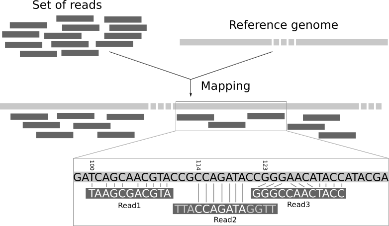

Figure 1: Mapping reads to a reference genome (https://shiltemann.github.io/)

**Genome alignment** approaches can be categorized as either core-genome alignment or whole-genome alignment based. Core-genome alignment based approaches involve identifying orthologous sequences present in all genomes in a set, while whole-genome alignment approaches extend alignment to regions not present in all genomes. [Parsnp](https://genomebiology.biomedcentral.com/articles/10.1186/s13059-014-0524-x) has become a popular tool for identifying SNPs in bacterial genomes using a core-genome alignment approach, due to its scalability (i.e., ability to query dozens, hundreds, and even thousands of closely related bacterial genomes) and speed (a major drawback that often plagues whole-genome alignment).

The **k-mer based** approach, as employed by reference-free SNP calling pipeline [kSNP](https://www.ncbi.nlm.nih.gov/pubmed/25913206), involves breaking up genomic data into odd-length k-mers, and then comparing the k-mers to each other, allowing the center nucleotide to vary.

#### 1.2.3.3 Input data format

SNP calling pipelines can additionally differ in terms of the types of input data which they require/can accept; some pipelines or tools require data to be short reads in fastq or gzipped fastq (fastq.gz) format, while others only support assembled genomes in fasta format. Some approaches may be additionally capable of utilizing both short reads, as well as assemblies (e.g., by fragmenting the contigs into synthetic “reads”).

#### 1.2.3.4 Filtering steps

SNP calling pipelines can differ in terms of the filtering steps which they employ. Examples of filtering steps include:

- Removing SNPs which align to phage regions (because mobile elements like phage can have different mutation rates)
- Removing SNPs which cluster closely together (because SNPs which occur close together may have been acquired via horizontal gene transfer, not mutation)
- Minimum read depth (for mapping based approaches, because we may be less confident in SNPs with few reads supporting them)
- Minimum quality or consensus thresholds (for mapping based approaches, because SNPs with conflicting allele calls may not actually be SNPs)

### 1.2.4 Selecting a SNP calling pipeline for your data

The “right” SNP calling pipeline depends on your data, as well as the goals of your experiment, and the [SNP calling pipeline you choose can greatly affect the quantity and identity of the SNPs you identify, as well the phylogeny you construct with those SNPs.](https://www.frontiersin.org/articles/10.3389/fmicb.2019.00144/full)

Some things to consider:

1. **How “closely related” are my samples?** Do they belong to the same ST? Serotype? Species? A reference-based approach is not generally a good idea if you’re working with isolates which are not closely related (e.g., different *Salmonella* serotypes, polyphyletic serotypes). However, if your isolates are known to be closely related (e.g., they belong to the same ST), the identification of high-quality (hqSNPs) using a reference-based approach is usually a goal to keep in mind.
2. **Do I have short reads available for my samples? Only assemblies? A combination?** Pipelines which rely on a read mapping approach (e.g., CFSAN) utilize reads in fastq.gz format as input, while others (e.g., Parsnp) can only use assembled genomes in fasta format as input. Other approaches may use a combination; for example, kSNP can use either assemblies or reads. snippy and LYVE-SET are designed primarily for identifying SNPs using reads as input but are capable of using assemblies for genomes for which no reads are available.
3. **How conservative do I want to be when identifying SNPs?** Some pipelines (e.g., CFSAN, LYVE-SET) employ strict filtering criteria to remove SNPs that do not meet specific conditions, meaning that they identify hqSNPs (i.e., the risk of a false positive [a SNP is called that is not actually a SNP] is low). As such, they remove “noisy” SNPs at the risk of removing true SNPs (i.e., they may remove a “true” SNP which does not meet the specified conditions). Pipelines like CFSAN and LYVE-SET are especially useful when analyzing WGS data associated with foodborne outbreaks (that’s actually what they were designed for!) because pairwise SNP differences between isolates are often used to determine whether an isolate should be included as part of an outbreak or cluster or not. In this scenario, a single SNP can determine whether an isolate is included or excluded!

In this Activity, as well as Activity 2.1, we will be identifying SNPs using three to four different pipelines (CFSAN is used in Supplemental Activity 2.1):

| Pipeline | Approach | Reference-based | Input data (file format) | Rationale |
| --- | --- | --- | --- | --- |
| kSNP | k-mer | No | Assemblies (fasta) | To identify core SNPs among all of our genomes and construct an initial phylogeny; to identify possible outliers; to identify possible reference genomes |
| Parsnp | Core-Genome Alignment | Yes | Assemblies (fasta) | To rapidly identify core SNPs in our genomes; to rapidly construct an initial phylogeny; as a sanity check to make sure our reference genome and isolate selection make sense |
| snippy | Read Mapping | Yes | Reads (fastq.gz) | To identify SNPs in closely related genomes using a reference-based, read-mapping approach |
| CFSAN | Read Mapping | Yes | Reads (fastq.gz) | To identify hqSNPs in closely related genomes associated with an outbreak |

Note: kSNP can also use reads as input, but for this Activity, we will use our assemblies

# 2 Activity 1.3

## 2.1 Identifying SNPs using a k-mer based approach

1. After accessing the remote workstation (see Activity 1.1, Section 2.1 for a refresher), we can initiate a new `tmux` session by running the following command:

```
tmux
```

2. Now that we’re in our tmux session, let’s make sure that we are starting from our home directory (`/home/myUsername`, where `myUsername` corresponds to your own username). To do so, `cd` (change directories) to your home directory (remember the `~` shortcut?):

```
cd ~
```

If we type `pwd` to print our current working directory, we should see we are in our home directory:

```
pwd
```

If we type `ls`, we should see that our `activity1` directory is still there:

```
ls
```

(If, for some reason, you accidentally deleted your `activity1` directory, have no fear! Just type `mkdir activity1` to create a new one)

2. To get started, we are going to want to use the assembled contigs of our Mystery *Salmonella* isolate (the fasta file from Activity 1.2). These should be in a directory within our `activity1` directory, so let’s move to our `activity1` directory:

```
cd activity1
```

If we type `pwd`, we should see that we are in `activity1`:

```
pwd
```

If we type `ls`, we should see the directory `mystery_salmonella_A_finished` listed among the contents of our current directory:

```
ls
```

3. Let’s copy the `contigs.fasta` file from our `mystery_salmonella_A_finished` directory to our current directory, `activity1`, and rename it to `mystery_salmonella_A.fasta` (`contigs.fasta` contains the assembled contigs of our Mystery Salmonella A isolate):

```
cp mystery_salmonella_A_finished/contigs.fasta ./mystery_salmonella_A.fasta
```

If we type `ls`, we should see `mystery_salmonella_A.fasta` listed among the files in our directory:

```
ls
```

(If, for some reason, you accidentally deleted your `activity1` directory, or if you deleted your `contigs.fasta` file, you can just copy the backup fasta file to your `activity1` directory with the following command: `cp /home/labinstructor/wgs_workshop/activity1_3/backup/mystery_salmonella_A.fasta .`)

4. For this activity, we’re going to be identifying SNPs in a set of 12 *Salmonella* genomes, including our mystery *Salmonella* genome, that we suspect may have been responsible for a foodborne outbreak.

| Isolate | Source | Location | Collection Date | Serotype | Part of Outbreak |
| --- | --- | --- | --- | --- | --- |
| A (Mystery *Salmonella* A) | Unknown | Unknown | Unknown | Unknown | Unknown |
| B | Food (Neptunian Slug) | Elzar’s Fine Cuisine | May 2, 2999 | Cerro | Yes |
| C | Food (Neptunian Slug) | Elzar’s Fine Cuisine | May 2, 2999 | Cerro | Yes |
| D | Human (feces) | Taco Bellevue Hospital, New New York | April 29, 2999 | Cerro | Yes |
| E | Human (feces) | Taco Bellevue Hospital, New New York | April 29, 2999 | Cerro | Yes |
| F | Human (feces) | Taco Bellevue Hospital, New New York | April 29, 2999 | Cerro | Yes |
| G | Human (feces) | Taco Bellevue Hospital, New New York | April 29, 2999 | Cerro | Yes |
| H | Human (feces) | Taco Bellevue Hospital, New New York | April 30, 2999 | Cerro | Unknown |
| I | Human (feces) | Taco Bellevue Hospital, New New York | May 1, 2999 | Cerro | Unknown |
| J | Human (feces) | Taco Bellevue Hospital, New New York | May 5, 2999 | Cerro | Unknown |
| K | Human (feces) | Taco Bellevue Hospital, New New York | May 5, 2999 | Cerro | Unknown |
| L | Human (feces) | Taco Bellevue Hospital, New New York | May 10, 2999 | Cerro | Unknown |

We know that **isolates B, C, D, E, F, and G are part of the outbreak**, but it is our job to **determine if isolates A, H, I, J, K, and L are as well**. To accomplish this, our eventual goal is to identify SNPs which we can use to construct a phylogeny which will allow us evaluate whether our isolates are part of the outbreak clade or not.

We are pretty sure that 11 of our 12 isolates belong to serotype Cerro because they underwent traditional serotyping; however, it is probably good to double-check this. Additionally, we don’t know the identity of isolate A. To determine whether we should include isolate A in our analysis, as well as to identify other potential outlier isolates, we’ll start by identifying SNPs in our 12 *Salmonella* genomes using a reference-free approach. To that end, we’ll use [kSNP](https://www.ncbi.nlm.nih.gov/pubmed/25913206), which employs a reference-free, k-mer based approach to identify SNPs. kSNP can use either assemblies or reads as input, but in our case, we’ll just use assembled genomes.

Now that we are in the same directory as our mystery *Salmonella* contigs file (`mystery_salmonella_A.fasta`), let’s create a new directory called `ksnp`:

```
mkdir ksnp
```

5. Let’s move the assembled contigs of our mystery *Salmonella* genome, `mystery_salmonella_A.fasta`, to our new `ksnp` directory:

```
mv mystery_salmonella_A.fasta ksnp
```

6. Now, let’s copy the assembled contigs of our 11 other *Salmonella* strains into our `ksnp` directory. You can find these files (in fasta format, just like our `mystery_salmonella_A.fasta`) in the `/home/labinstructor/wgs_workshop/activity1_3/assemblies` directory.

If we type `ls` and supply the path to the `assemblies` directory, we’ll see that there are 11 assemblies, each named according to the following convention: **StrainID_Source_Month-Day-Year_TraditionalSerotype_PartOfOutbreak.fasta**

```
ls /home/labinstructor/wgs_workshop/activity1_3/assemblies
```

All of these genomes were assembled from Trimmomatic-trimmed paired-end Illumina reads using SPAdes, just as we did for our mystery *Salmonella* A genome.

We can copy all of these assemblies to our `ksnp` directory using the following command:

```
cp /home/labinstructor/wgs_workshop/activity1_3/assemblies/*.fasta ksnp
```

With this command, we are telling the computer to copy everything in the `/home/labinstructor/wgs_workshop/activity1_3/assemblies` directory which ends with the suffix `.fasta`, and store a copy in `ksnp`.

If we type `ls` and supply the path to `ksnp`, we should see our 12 genomes listed:

```
ls ksnp
```

7. Now, let’s add kSNP3 and its associated scripts to our path by running the following command (we need to do this so kSNP will run properly):

```
PATH=$PATH:/opt/kSNP3.1_Linux_package/kSNP3
```

8. According to [the manual](http://gensoft.pasteur.fr/docs/kSNP3/01/kSNP3.01%20User%20Guide%20.pdf), kSNP requires an input list file which lists (i) the paths to all of the genomes in which we want to call SNPs, and (ii) their genome identifiers, separated by a tab. Luckily, we can use kSNP’s `MakeKSNP3infile` command to create this for us!

Let’s run `MakeKSNP3infile`, using its “automatic” mode (the `MakeKSNP3infile` function also has a semi-automatic mode which writes just the paths to the input files, i.e., it doesn’t guess the names of the genomes; we will use automatic mode because we want to use the names already assigned to our genomes).

The general format for running `MakeKSNP3infile` in automatic mode is as follows (note: don’t execute this command; it is just an example):

```
MakeKSNP3infile </path/to/directory/with/genomes.fasta> infile_name.txt A
```

With this command, we are calling the `MakeKSNP3infile` function, telling kSNP where our genomes are located, specifying what we want to name the input list of our genomes which we will supply to kSNP (`infile_name.txt`), and telling kSNP to guess our genome names by specifying automatic mode (`A`).

Let’s try it ourselves by running the following command; this tells kSNP that all of our genomes are in our `ksnp` directory and creates a kSNP input file named `ksnp_infile.txt` (although we can technically name it whatever we want):

```
MakeKSNP3infile ksnp ksnp_infile.txt A
```

If we type `ls` to list the files in our current directory (`activity1`), we should see a file named `ksnp_infile.txt`:

```
ls
```

If we use `cat` to print the contents of `ksnp_infile.txt`, we should see paths to all twelve of our genomes, as well as their names, separated by a tab:

```
cat ksnp_infile.txt
```

9. Now, we have to create a concatenated file of all of our genomes for kSNP. Luckily, kSNP has a function for that, too!

`MakeFasta` will concatenate our genomes (note: don’t execute this command; it is just an example):

```
MakeFasta infile_name.txt output.fasta
```

This command calls kSNP’s `MakeFasta` function and tells it that we want to create a fasta file of all of the genomes listed in `infile_name.txt`. It then saves this concatenated fasta as `output.fasta`.

Let’s try it ourselves (we’ll name our concatenated fasta file `salmonella.fasta`, although we could technically name it anything):

```
MakeFasta ksnp_infile.txt salmonella.fasta
```

If we type `ls -lh`, we should see that we have a relatively large file named `salmonella.fasta` deposited in our current directory:

```
ls -lh
```

10. Now, kSNP has to decide which k-mer size it should use to call SNPs. To select the optimal size, kSNP has a function, `Kchooser`. Kchooser assumes that no more that 1% of the genome is duplicated sequences, and tests different k-mer sizes, starting with k = 13 and then incrementing the k-mer size in steps of 2 (i.e., k = 13, 15, 17…) until it estimates that 99% of the median length genome is unique. To run `Kchooser`, we just call `Kchooser`, and supply the path to our concatenated fasta (`salmonella.fasta`):

```
Kchooser salmonella.fasta
```

After waiting a bit, we should see that the optimal k-mer size for our *Salmonella* genomes is 19.

11. We can now delete our concatenated fasta, `salmonella.fasta`, because we don’t need it anymore:

```
rm salmonella.fasta
```

12. Now, we can finally use kSNP to identify core SNPs in our 12 *Salmonella* genomes! kSNP has a lot of options to play with, but for this Activity, we will use a command that takes the following form (note: don’t execute this command; it is just an example):

```
kSNP3 -in <infile_name.txt> -outdir </path/to/output_directory> -k <optimal k-mer size from Kchooser> -core -CPU <number of processors to use>
```

With this command, we:

- Call kSNP3 (`kSNP3`)
- Specify the path to the input file which contains the paths to all of our genomes (`-in`)
- Specify the path/name of the directory in which we want to deposit the output files produced by kSNP (`-outdir`)
- Tell kSNP which k-mer size we want to use, i.e., the optimal k-mer size determined by Kchooser (`-k`)
- Tell kSNP that we want to identify core SNPs (i.e., SNPs present in all genomes) (`-core`)
- Tell kSNP how many processors it should use; if you don’t supply this, it will use all available processors (`-CPU`)

Let’s run the following command to identify core SNPs present in all 12 of our genomes, and to construct a maximum likelihood tree using those core SNPs (we’ll discuss maximum likelihood in the next lecture/Activity!):

```
kSNP3 -in ksnp_infile.txt -outdir ksnp_out -k 19 -core -ML -CPU 4 | tee kSNP_log
```

With this command, we:

- Call kSNP3 (`kSNP3`)
- Specify the path to our input file, `ksnp_infile.txt`, which contains the paths to all of our genomes (`-in ksnp_infile.txt`)
- Specify the path to the directory in which we want to deposit the output files produced by kSNP; we could name this anything, but we’ll tell kSNP to make a new output directory in our current directory named `ksnp_out` and deposit all output files there (`-outdir ksnp_out`)
- Tell kSNP that we want to use a k-mer size of 19, based on our results from Kchooser (`-k 19`)
- Tell kSNP that we want to identify core SNPs present in all 12 of our genomes (`-core`)
- Tell kSNP that we want to construct a Maximum Likelihood (ML) tree using FastTree, treating the SNPs we identify as input (`-ML`)
- Tell kSNP that we want to use 4 processors, just because we will all be running this command at once (`-CPU 4`)
- Create a log file named `kSNP_log`, just in case we get an error
13. kSNP will take a while (~30 minutes) to run; let’s detach our tmux session and work on something else; to detach our current session, hold the `ctrl` and `b` keys at the same time, release, and then press the `d` key (no need to hit enter! It will detach when you press `d`).

## 2.2 *In silico Salmonella* serotyping

1. In addition to allowing us to query bacterial genomes in their entirety, WGS can be used to replicate many traditional typing and phenotypic analyses *in silico*. One tool, [SISTR](https://lfz.corefacility.ca/sistr-app/), can be used to predict *Salmonella* serotype *in silico*.

Let’s use SISTR to see if we can predict the serotype of our mystery *Salmonella* isolate, as well as confirm that the remaining 11 *Salmonella* genomes belong to serotype Cerro. First, let’s move into our `ksnp` directory, which houses all 12 of our *Salmonella* genomes:

```
cd ksnp
```

If we type `ls`, we should see all 12 of our genomes:

```
ls
```

If we type `pwd`, we should see that we are in our `ksnp` directory:

```
pwd
```

2. The general format for running SISTR using an assembled *Salmonella* genome is as follows (note: don’t execute this command; it is just an example):

   ```
   sistr -i </path/to/salmonella_genome.fasta> <salmonella_genome_name> -f <output format [json, csv, pickle]> --qc -o </path/to/output_prefix> -t <number of threads>
   ```

Let’s run the following command to serotype our mystery *Salmonella* genome, `mystery_salmonella_A.fasta`:

```
sistr -i mystery_salmonella_A.fasta mystery_salmonella_A -f csv --qc -o mystery_salmonella_A_sistr -t 1
```

By running this command, we are:

- Calling SISTR (`sistr`)
- Telling SISTR that we want to serotype our genome, `mystery_salmonella_A.fasta`, and assign it the name `mystery_salmonella_A` (`-i mystery_salmonella_A.fasta mystery_salmonella_A`)
- Telling SISTR to save our results in `csv` format (`-f csv`)
- Telling SISTR to perform basic quality control to provide the level of confidence in serovar prediction results (`--qc`)
- Telling SISTR to save our output with the prefix `mystery_salmonella_A_sistr` (`-o mystery_salmonella_A_sistr`)
- Telling SISTR to use one thread (`-t 1`)
3. SISTR should finish running after a few seconds. When it’s done, you can type `ls` to list the contents of your current directory (`ksnp`); you should see a file named `mystery_salmonella_A_sistr.csv` among the files listed:

```
ls
```

We can view the comma-separated output file SISTR produced by using `cat`:

```
cat mystery_salmonella_A_sistr.csv
```

SISTR lists some information, including a core-genome multi-locus sequence type (cgMLST) (the first entry), as well as the predicted serotype using both an antigen-based typing method and a cgMLST-based typing method (the last two entries). What serotype is our mystery *Salmonella* isolate predicted to belong to? (Spoiler alert below! Take a look before reading the next steps!)

4. Let’s use SISTR to serotype the rest of our genomes. Rather than type the `sistr` command 11 more times, let’s run the command in a script that loops through all of our *Salmonella* genomes, running SISTR on each one.

The script we will run, `sistr_loop.sh`, looks like this (note: don’t execute the following; it is just an example):

```
#!/bin/bash

for f in *.fasta
do
sistr -i ./$f ${f%.fasta} -o ${f%.fasta} -f csv --qc -t 1 --verbose
done
```

With this script, we are telling bash to loop through all files ending in .fasta in our current directory (i.e., all of our assembled genomes) and run `sistr` with each genome as input, exactly as we did above.

A copy of this script, `sistr_loop.sh`, is stored in the `/home/labinstructor/wgs_workshop/activity1_3/scripts` directory. Let’s copy it to our current directory (`ksnp`; we can just use `.` to denote our current directory):

```
cp /home/labinstructor/wgs_workshop/activity1_3/scripts/sistr_loop.sh .
```

5. To run `sistr_loop.sh`, run the following command:

```
sh sistr_loop.sh
```

6. Once `sistr_loop.sh` finishes, we can take a look at all of our serotypes with the following one-liner:

```
cat *.csv | grep -v "cgmlst_distance"
```

This command concatenates all of our csv files (produced by SISTR), and “greps” (i.e., matches) any lines of the concatenated file that do NOT (because of the `-v` option) contain the pattern `cgmlst_distance` (i.e., we will print all of the lines with our serotypes). What serotypes do our isolates belong to? (Spoiler alert below! Take a look before reading the next steps!)

## 2.3 Identifying outliers in WGS data using phylogenomic and typing analyses

1. Let’s check on our kSNP results to see if they have finished; we can attach our `tmux` session with the following command:

```
tmux attach
```

Regardless of whether kSNP has finished running, detach your tmux session by holding the `ctrl` and `b` keys at the same time, releasing, and then pressing the `d` key (no need to hit enter! It will detach when you press `d`).

2. Let’s move to our `activity1` directory:

```
cd ~/activity1
```

3. kSNP produces numerous output files, depending on the options you run. We can view the results of a pre-computed kSNP run, which were obtained by running the exact commands you used to run kSNP above:

```
ls /home/labinstructor/wgs_workshop/activity1_3/ksnp/
```

For this activity, we are particularly interested in the phylogenetic tree that kSNP produced using core SNPs detected in all 12 of our *Salmonella* genomes (don’t worry; we will construct our own phylogeny in the next Activity!). This phylogeny should be titled `/home/labinstructor/wgs_workshop/activity1_3/ksnp/tree.core.tre`:

```
ls /home/labinstructor/wgs_workshop/activity1_3/ksnp/tree.core.tre
```

4. Use `scp` (Mac) or WinSCP (or your favorite file transfer client; Windows) to copy `/home/labinstructor/wgs_workshop/activity1_3/ksnp/tree.core.tre` to your own computer.
5. If you don’t already have [FigTree](https://github.com/rambaut/figtree/releases) installed on your computer, download and install the version appropriate for your operating system now.
6. Open FigTree, and click “File” -> “Open” -> and select `tree.core.tre` to open it.
7. We can use FigTree to annotate our phylogeny. Let’s color the tip labels corresponding to the strains known to be asssociated with the *Salmonella* outbreak so that we can tell them apart from the mystery isolates.

Because all of our known outbreak isolates have the pattern “_OutbreakYes" in their genome names, we can highlight them all at once by matching this pattern. In the search bar at the upper right corner of the FigTree window, type in `_OutbreakYes`. FigTree will highlight the outbreak isolates (i.e., the tip labels containing “_OutbreakYes“). Click”Colour" in the toolbar above the phylogeny, and select any non-black color you feel like (our mystery isolate names should remain black).

What do you notice about some of our mystery isolates? How does this align with the *in silico* serotyping results we got from SISTR? Are there any genomes that you think we should exclude from the outbreak and, thus, reference-based SNP identification? Why or why not? (Spoiler alert below! Take a look before reading the next steps!)

## 2.4 Rapidly identify core SNPs in assembled bacterial genomes using Parsnp’s reference-based core genome alignment approach

[Parsnp](https://harvest.readthedocs.io/en/latest/content/parsnp.html) is a popular tool for rapidly identifying core SNPs in bacterial genomes using a reference-based approach. Parsnp is fast, scalable (i.e., you can easily query dozens, hundreds, and even thousands of genomes), and very user friendly, making it a good choice for testing different reference genomes and getting an initial idea of what your phylogeny might look like prior to identifying SNPs using a reference-based mapping approach. It even comes with its own file manipulation and alignment/phylogeny viewing software, [HarvestTools](https://harvest.readthedocs.io/en/latest/content/harvest-tools.html) and [Gingr](https://harvest.readthedocs.io/en/latest/content/gingr.html), respectively, which make it easy to interact with your data.

1. Move to your `activity1` directory, if you aren’t there already:

```
cd ~/activity1
```

2. Let’s create a new directory for parsnp, named `parsnp`, which will contain our input files:

```
mkdir parsnp
```

3. Parsnp uses assembled genomes as input; as such, let’s copy the assembled genomes for our putative outbreak isolates into our `parsnp` directory:

```
cp /home/labinstructor/wgs_workshop/activity1_3/assemblies/*.fasta parsnp
```

4. After looking at our core SNP phylogeny produced using a reference-free k-mer based SNP calling approach (kSNP), as well as the results from SISTR, you probably have an idea as to which genomes we should exclude. The genomes we will be excluding (and the rationale for doing so) are:
- mystery_salmonella_A: belongs to serotype Typhimurium, not Cerro (see results from SISTR; kSNP)
- I_HUMN_05-01-2999_Cerro_OutbreakUnknown: belongs to serotype Newport, not Cerro (see results from SISTR; kSNP)
- H_HUMN_04-30-2999_Cerro_OutbreakUnknown: belongs to a completely different lineage of Cerro ([Cerro is polyphyletic!](https://mbio.asm.org/content/9/6/e02303-18)) (see results from kSNP)
- J_HUMN_05-05-2999_Cerro_OutbreakUnknown: belongs to a completely different lineage of Cerro ([Cerro is polyphyletic!](https://mbio.asm.org/content/9/6/e02303-18)) (see results from kSNP)

Because Parsnp uses a reference-based approach, and we don’t want to include genomes that don’t belong to our outbreak lineage, let’s delete the following assemblies from our `parsnp` directory:

To remove genome I (the Newport genome):

```
rm parsnp/I_HUMN_05-01-2999_Cerro_OutbreakUnknown.fasta
```

To remove genome H (belongs to the non-outbreak polyphyletic Cerro lineage):

```
rm parsnp/H_HUMN_04-30-2999_Cerro_OutbreakUnknown.fasta
```

To remove genome J (belongs to the non-outbreak polyphyletic Cerro lineage):

```
rm parsnp/J_HUMN_05-05-2999_Cerro_OutbreakUnknown.fasta
```

5. Because Parsnp employs a reference-based approach, we need to select an assembled reference genome in fasta format. Selecting a reference genome is [not trivial](https://www.ncbi.nlm.nih.gov/pmc/articles/PMC4140716/), and there are a few things to consider when selecting one:

### 2.4.1 How close is “close enough” for a reference genome?

The ideal reference genome should be phylogenomically and evolutionarily “close” to the isolates being queried. A reference genome that is too far away from the genomes of interest can affect [which SNPs are (or aren’t) identified](https://www.frontiersin.org/articles/10.3389/fmicb.2019.00144/full), as well as [the topology of the resulting phylogeny.](https://www.ncbi.nlm.nih.gov/pmc/articles/PMC5798827/) This is especially important when deciding whether to include an isolate as part of a foodborne outbreak or not.

Some do’s and don’ts which can guide you in your quest for a “close” reference genome include:

- **DO make sure your reference genome belongs to the same species as the genomes you are querying**

This sounds like it should be obvious, but it may not always be intuitive, particularly in bacterial species where distantly related organisms share the same name (e.g., [*Bacillus cereus* and emetic *Bacillus cereus*](https://www.frontiersin.org/articles/10.3389/fmicb.2019.00144/full))

- **DO make sure your your reference genome belongs to the same major “lineage” as the genomes you are querying**

In the case of *Salmonella enterica*, a good way to start is by using *in silico* serotyping (e.g., as we did with SISTR) to ensure that the proposed reference genome belongs to the same serotype as the isolates of interest. Calling SNPs using a reference genome belonging to a different serotype (e.g., [using a *Salmonella* Dublin reference genome when querying a set of *Salmonella* Heidelberg genomes](https://www.ncbi.nlm.nih.gov/pmc/articles/PMC5798827/)) affects the resulting genetic distances of isolates and the resolution of the resulting phylogeny.

However, as you hopefully learned from our activity, some *Salmonella* serotypes are [polyphyletic](https://mbio.asm.org/content/9/6/e02303-18) (e.g., Cerro, Kentucky, Newport), meaning they have been grouped together based on their serotype, but they do not share an immediate common ancestor. As such, it is usually a good idea to perform *in silico* MLST, cgMLST, or some other typing method to ensure that all of your genomes belong to the same (or at least a very similar) ST.

- **DON’T attempt to identify SNPs in distantly related organisms using a reference-based approach**

As mentioned above, beware of polyphyletic serotypes, and be on the lookout for mislabeled or misclassified organisms. Many taxonomic designations in NCBI are based on what users provide. For example, a scientist serotyped a *Salmonella* isolate as Cerro, so they are submitting its genome as Cerro when it actually belongs to a Newport lineage (traditional serotyping can sometimes be wrong); a different scientist sequenced the 16S gene of a *Bacillus* isolate and submitted it as *Bacillus anthracis*, but 16S can’t differentiate between *B. anthracis* and closely related species (both of these things have happened to me!). Always make sure you are working with what you think you are working with (e.g., perform *in silico* typing prior to reference-based SNP calling to make sure your *Salmonella* belongs to the correct species, serotype, etc.)

### 2.4.2 Closed versus draft reference genome

Many researchers opt to use a closed genome (e.g., downloaded from an external database such as [NCBI’s Assembly](https://www.ncbi.nlm.nih.gov/assembly) database or [EnteroBase](https://enterobase.warwick.ac.uk/)) in favor of draft genomes. Closed genomes are convenient because the exact position of each base is known, and there are no gaps in the sequence which could potentially contain informative SNPs (the chromosome is one giant contig). Because they are partitioned into chromosomes and plasmids, one can explicitly exclude or include extrachromosomal SNPs (i.e., those found in plasmids). Additionally, closed genomes are often derived from commonly studied organisms or strains, and there may be a lot of valuable information (e.g., relevant studies, thorough annotations) out there for the organisms from which they are derived.

However, in some situation, a quality finished genome that is “close enough” to your genomes of interest may not be available. All is not lost because [high-quality draft genomes can be used as reference genomes for reference-based SNP calling](https://www.ncbi.nlm.nih.gov/pmc/articles/PMC5798827/) and have been shown to [have little influence on the number and identity of SNPs identified using reference-based approaches](https://www.frontiersin.org/articles/10.3389/fmicb.2019.00144/full). This is fortunate because, as of the time of this workshop, there are no publicly available closed *Salmonella* Cerro genomes belonging to our sequence type.

Following this, let’s use `G_HUMN_04-29-2999_Cerro_OutbreakYes.fasta`, one of our outbreak isolate genomes, as a reference. We know it is phylogenomically close to our isolates of interest (because it is one!), and we don’t have the option of using a publicly available closed genome belonging to the same ST, anyway, because none exist.

Let’s specify G_HUMN_04-29-2999_Cerro_OutbreakYes.fasta as our reference for Parsnp. Because Parsnp includes the reference genome in its final alignment and tree files, let’s move G_HUMN_04-29-2999_Cerro_OutbreakYes.fasta out of our `parsnp` directory and into our current one (`activity1`). That way, Parsnp does not include G_HUMN_04-29-2999_Cerro_OutbreakYes.fasta twice in the alignments or tree that it outputs):

```
mv parsnp/G_HUMN_04-29-2999_Cerro_OutbreakYes.fasta .
```

6. Now, let’s run the following command to run Parsnp:

   ```
   /opt/Parsnp-Linux64-v1.2/parsnp -r G_HUMN_04-29-2999_Cerro_OutbreakYes.fasta -d parsnp -p 1 -x -o parsnp_out
   ```

With this command, we are:

- Calling Parsnp (`/opt/Parsnp-Linux64-v1.2/parsnp`)
- Telling Parsnp that we want G_HUMN_04-29-2999_Cerro_OutbreakYes.fasta to be our reference genome (`-r G_HUMN_04-29-2999_Cerro_OutbreakYes.fasta`)
- Telling Parsnp that we want to use the assemblies in `parsnp` as input (`-d parsnp`)
- Telling Parsnp that we want to filter recombination events (`-x`)
- Telling Parsnp to output our results in a directory named `parsnp_out` (`-o parsnp_out`)
7. When Parsnp finishes running, type `ls` to check out the files in our output directory, `parsnp_out`:

```
ls parsnp_out
```

8. Using `scp` (Mac) or WinSCP (or your favorite scp client; Windows), copy the `parsnp.ggr` file that it produced (the path to the file should be `~/activity1/parsnp_out/parsnp.ggr`) to your own computer.
9. Download and install [Gingr](https://harvest.readthedocs.io/en/latest/content/gingr.html) to open `parsnp.ggr` on your own computer and view an interactive phylogeny and alignment.

## 2.5 Constructing a phylogeny using IQ-TREE and core SNPs identified with Parsnp and HarvestTools

Parsnp uses [FastTree2](https://journals.plos.org/plosone/article?id=10.1371/journal.pone.0009490) to construct maximum likelihood phylogenies. However, we may want to construct a maximum likelihood phylogeny using a different tree building program, such as IQ-TREE. [IQ-TREE, while slower, has been shown to outperform FastTree2, which Parsnp uses to construct its initial phylogeny](https://www.ncbi.nlm.nih.gov/pmc/articles/PMC5850867/). Additionally, we can perform nucleotide substitution model selection using ModelFinder as implemented in IQ-TREE.

Here, we will use our core SNPs identified by Parsnp as input for IQ-TREE. For a more in-depth discussion of IQ-TREE (and phylogeny construction in general), see Activity 2.1.

1. Move to your `activity1` directory, if you aren’t there already:

```
cd ~/activity1
```

2. Let’s move into our `parsnp_out` directory:

```
cd parsnp_out
```

If we type `pwd` to print our working directory, we should see that we are in `parsnp_out`:

```
pwd
```

3. We are interested in obtaining a fasta file that only contains SNPs detected in our putative outbreak genomes (i.e., we want to exclude invariant sites). While Parsnp doesn’t directly output a fasta containing SNPs, we can use Parsnp’s companion data manipulation toolkit, [HarvestTools](https://harvest.readthedocs.io/en/latest/content/harvest-tools.html), to produce this. To do this, run the following command:

```
/opt/harvesttools-Linux64-v1.2/harvesttools -i parsnp.ggr -S parsnp.fasta
```

With this command, we:

- Call HarvestTools (`/opt/harvesttools-Linux64-v1.2/harvesttools`)
- Tell HarvestTools to use the `parsnp.ggr` file which Parsnp produced as input (`-i parsnp.ggr`)
- Tell HarvestTools to output SNPs in fasta format; we could name this fasta file anything, but let’s name ours “parsnp.fasta” (`-S parsnp.fasta`)
4. Let’s run IQ-TREE, using our `parsnp.fasta` file of SNPs as input:

```
/opt/iqtree-1.6.10-Linux/bin/iqtree -s parsnp.fasta -bb 1000 -m MFP+ASC
```

With this command, we are:

- Calling IQ-TREE (`/opt/iqtree-1.6.10-Linux/bin/iqtree`)
- Telling IQ-TREE that we want to use the SNPs identified by Parsnp as our input sequence alignment (`-s parsnp.fasta`)
- Telling IQ-TREE to perform 1,000 replicates of the Ultrafast Bootstrap test of branch support (`-bb 1000`)
- Telling IQ-TREE to use ModelFinder to select the optimal nucleotide substitution model for our data, testing only models that account for the fact that all of our sites are SNPs (i.e., it only tests models that apply an ascertainment bias correction that accounts for the use of solely variant sites) (`-m MFP+ASC`)
5. When IQ-TREE finishes, copy the `parsnp.fasta.treefile` file which IQ-TREE creates to your own computer using `scp` (Mac) or WinSCP (or your favoite scp client; Windows) (the path to the file should be `~/activity1/parsnp_out/parsnp.fasta.treefile`). Open your phylogeny constructed using IQ-TREE/Parsnp+HarvestTools in FigTree (or your favorite phylogeny viewer).

Additionally, you can copy the `parsnp.tree` file which Parsnp created using its implementation of FastTree2 to your own computer and open it; how does it compare to the phylogeny you constructed using IQ-TREE?

6. Copy `parsnp.fasta.log` to your own computer, and open it in your favorite text editor. Can you find which nucleotide substitution model IQ-TREE/ModelFinder selected as the optimal model for your data? Note that [there has been some debate as to whether nucleotide substitution model selection is mandatory for nucleotide data](https://www.nature.com/articles/s41467-019-08822-w) (i.e., not amino acid sequences).

ModelFinder selected the optimal model using the **Bayesian information criterion (BIC)** values calculated for each of our nucleotide substitution models, where BIC is defined as:

BIC = ln(n)k - 2 ln(L)

where L is the maximized value of the likelihood function of model M, n is the number of observations, and k is the number of parameters estimated by the model.

ModelFinder selected the model with the lowest BIC value.

# 3 Supplemental Activities

Have extra time? The following Supplemental Readings and Activities are designed to give you extra practice with some of the tools and/or topics covered in this Activity, as well as to introduce some new concepts for participants who want an extra challenge. Feel free to work on all of the activities/readings, or pick your favorite (or, feel free to work on your own projects, or just relax!).

## 3.1 Supplemental Readings

**Topic: developing and comparing different approaches for identifying SNPs in bacterial genomes**

Carroll, et al. 2019. [Characterization of Emetic and Diarrheal *Bacillus cereus* Strains From a 2016 Foodborne Outbreak Using Whole-Genome Sequencing: Addressing the Microbiological, Epidemiological, and Bioinformatic Challenges.](https://www.frontiersin.org/articles/10.3389/fmicb.2019.00144/full) *Frontiers in Microbiology* 10:144. DOI: 10.3389/fmicb.2019.00144.

Katz, et al. 2017. [A Comparative Analysis of the Lyve-SET Phylogenomics Pipeline for Genomic Epidemiology of Foodborne Pathogens.](https://www.ncbi.nlm.nih.gov/pmc/articles/PMC5346554/) *Frontiers in Microbiology* 8: 375. DOI: 10.3389/fmicb.2017.00375.

Olson, et al. 2015. [Best practices for evaluating single nucleotide variant calling methods for microbial genomics.](https://www.ncbi.nlm.nih.gov/pmc/articles/PMC4493402/) *Frontiers in Microbiology* 6: 235. DOI: 10.3389/fgene.2015.00235

## 3.2 *In silico* MLST

1. In addition to predicting *Salmonella* serotypes *in silico*, we can also perform multi-locus sequence typing (MLST) *in silico*. We will do this using `seq2mlst`, which uses nucleotide blastn (blastn) to identify the top allelic types for each allele, as well as the corresponding ST.

First, let’s move to our `ksnp` directory:

`cd ~/activity1/ksnp`

2. The `seq2mlst` executable (i.e., a script) and its associated database files are stored in `/home/labinstructor/wgs_workshop/activity1_3/scripts/seq2mlst`. Let’s recursively copy the executable and database directory to our current directory (we are using the `-r` option for recursive because the database files are in a directory, and we want to copy the whole directory):

```
cp -r /home/labinstructor/wgs_workshop/activity1_3/scripts/seq2mlst/* .
```

3. Now let’s create a directory named `seq2mlst_out`, where `seq2mlst` will deposit our results:

```
mkdir seq2mlst_out
```

And let’s install biopython for python2, which we need to run seq2mlst:

```
pip2 install --user biopython
```

4. The general format for running `seq2mlst` with an assembled genome is as follows (note: don’t execute the following; it is just an example):

```
python seq2mlst -i </path/to/input/genome> -o </path/to/output/directory> -t [seq,se,pe,sra,sra-get] -m "Genus species" --draft_genome
```

By running this command, we are:

- Calling python (`python`)
- Telling python to execute the program, `seq2mlst` (`seq2mlst`)
- Specifying the path to an input genome (`-i`)
- Specifying the path to an output directory where `seq2mlst` will deposit the results (`-o`)
- Specifying the format of our input data; either `seq` for an assembled sequence, `se` for single-end reads, `pe` for paired-end reads, `sra` for a file in NCBI’s Sequence Read Archive (SRA) format, or `sra-get` for an SRA accession number (`-t`)
- Telling `seq2mlst` to use the MLST scheme for a particular organism (`-m`)
- If we use the `-t seq` option to specify that we are using assembled genomes as input, we can also specify whether our genomes are draft genomes (i.e., contigs or scaffolds that should be concatenated together) or closed genomes (i.e., a single sequence)

Like we did with SISTR, let’s run `seq2mlst` in a loop (so we don’t have to type the command 12 times!). We will run the `seq2mlst.sh` script, which contains the following commands (note: don’t execute the following; it is just an example) :

```
#!/bin/bash

for f in *.fasta
do
python seq2mlst -i $f -o seq2mlst_out -t seq --draft_genome -m "Salmonella enterica"
rm seq2mlst_out/*.fasta
done
```

With this script we are:

- Calling the bash shell (`#!/bin/bash`)
- Looping through each of the fasta files in our current directory (i.e., each of our 12 assembled genomes), so that we can run `seq2mlst` on each (`for f in *.fasta`)
- Calling `python` and telling it to execute the `seq2mlst` script; it will treat the current fasta file, `$f` as input for `seq2mlst` (`-i $f`), and it will deposit all of the output in the directory we created, `seq2mlst_out`. Additionally, we are telling `seq2mlst` that our genomes are draft genomes (i.e., contigs) in fasta format (`-t seq --draft_genome`), and we are telling it to use the seven-gene MLST scheme for `Salmonella enterica` (we could technically specify any organism in [PubMLST](https://pubmlst.org/databases/)).
- Deleting the intermediate pseudochromosome fasta files that seq2mlst deposits in our output directory; `seq2mlst` creates these fasta files when the `--draft_genome` option is added (it just concatenates all of the contigs together with a spacer of Ns; `rm seq2mlst_out/*.fasta`)

Let’s run `seq2mlst.sh` using the command below:

```
sh seq2mlst.sh
```

5. When `seq2mlst` finishes, let’s take a look at some of the output that it deposited in our `seq2mlst_out` directory by typing `ls` and supplying the path to `seq2mlst_out`:

```
ls seq2mlst_out
```

We should see a directory named `seq2mlst_final_results`.

6. Now, let’s take a look at what is in the directory named `seq2mlst_final_results`:

```
ls seq2mlst_out/seq2mlst_final_results
```

We should see 12 files ending in the suffix `_final_results.txt` (one for each input genome) and 2 directories (`genefiles`, which contains the sequences of all of our MLST loci for each isolate, and `isolatefiles`, which contains additional results for each isolate).

Take a look at some of the output files. What ST do the outbreak isolates have? The non-outbreak isolates? Do any of these results surprise you?

# 4 References

Abadi, Azouri, Pupko, and Mayrose. 2019. [Model selection may not be a mandatory step for phylogeny reconstruction.](https://www.nature.com/articles/s41467-019-08822-w) *Nature Communications*. 10(1):934. DOI: 10.1038/s41467-019-08822-w.

Alikhan, et al. 2018. [A genomic overview of the population structure of *Salmonella*.](https://journals.plos.org/plosgenetics/article?id=10.1371/journal.pgen.1007261) *PLoS Genetics* 14(4):e1007261. DOI: 10.1371/journal.pgen.1007261.

Carroll, et al. 2019. [Characterization of Emetic and Diarrheal *Bacillus cereus* Strains From a 2016 Foodborne Outbreak Using Whole-Genome Sequencing: Addressing the Microbiological, Epidemiological, and Bioinformatic Challenges.](https://www.frontiersin.org/articles/10.3389/fmicb.2019.00144/full) *Frontiers in Microbiology* 10:144. DOI: 10.3389/fmicb.2019.00144.

Davis, et al. 2015. [CFSAN SNP Pipeline: an automated method for constructing SNP matrices from next-generation sequence data.](https://peerj.com/articles/cs-20/) *PeerJ Computer Science*. DOI: 10.7717/peerj-cs.20.

Farhat, et al. 2013. [Genomic analysis identifies targets of convergent positive selection in drug-resistant *Mycobacterium tuberculosis*.](https://www.nature.com/articles/ng.2747) *Nature Genetics* 45(10):1183-9. DOI: 10.1038/ng.2747.

Franz, et al. 2018. [Phylogeographic Analysis Reveals Multiple International transmission Events Have Driven the Global Emergence of *Escherichia coli* O157:H7](https://academic.oup.com/cid/advance-article-abstract/doi/10.1093/cid/ciy919/5146342?redirectedFrom=fulltext). *Clinical Infectious Diseases* DOI: 10.1093/cid/ciy919.

Gardner and Hall. 2013. [When Whole-Genome Alignments Just Won’t Work: kSNP v2 Software for Alignment-Free SNP Discovery and Phylogenetics of Hundreds of Microbial Genomes.](https://journals.plos.org/plosone/article?id=10.1371/journal.pone.0081760) *PLoS One* 8(12): e81760.

Gardner, Slezak, and Hall. 2015. [kSNP3.0: SNP detection and phylogenetic analysis of genomes without genome alignment or reference genome.](https://www.ncbi.nlm.nih.gov/pubmed/25913206) *Bioinformatics* 31(17):2877-8. DOI: 10.1093/bioinformatics/btv271.

Gymoese, et al. 2017. [Investigation of Outbreaks of *Salmonella enterica* Serovar Typhimurium and Its Monophasic Variants Using Whole-Genome Sequencing, Denmark.](https://www.ncbi.nlm.nih.gov/pubmed/28930002) *Emerging Infectious Diseases* 23(10):1631-1639. DOI: 10.3201/eid2310.161248.

Kalyaanamoorthy, et al. 2017. [ModelFinder: fast model selection for accurate phylogenetic estimates.](https://www.nature.com/articles/nmeth.4285) *Nature Methods* 14: 587–589. DOI: https://doi.org/10.1038/nmeth.4285.

Katz, et al. 2017. [A Comparative Analysis of the Lyve-SET Phylogenomics Pipeline for Genomic Epidemiology of Foodborne Pathogens.](https://www.ncbi.nlm.nih.gov/pmc/articles/PMC5346554/) *Frontiers in Microbiology* 8: 375. DOI: 10.3389/fmicb.2017.00375.

Laabei, et al. 2014. [Predicting the virulence of MRSA from its genome sequence.](https://www.ncbi.nlm.nih.gov/pmc/articles/PMC4009613/) *Genome Research* 24(5): 839–849.

Mather, et al. 2013. [Distinguishable Epidemics Within Different Hosts of the Multidrug Resistant Zoonotic Pathogen *Salmonella* Typhimurium DT104.](https://www.ncbi.nlm.nih.gov/pmc/articles/PMC4012302/) *Science* 1514-7. DOI: 10.1126/science.1240578.

Minh, Nguyen, and von Haeseler. 2013. [Ultrafast Approximation for Phylogenetic Bootstrap.](https://academic.oup.com/mbe/article/30/5/1188/997508) *Molecular Biology and Evolution* 30(5): 1188–1195. DOI: https://doi.org/10.1093/molbev/mst024

Moura, et al. 2017. [Real-Time Whole-Genome Sequencing for Surveillance of *Listeria monocytogenes*, France.](https://www.ncbi.nlm.nih.gov/pubmed/28643628) *Emerging Infectious Diseases* 23(9):1462-1470. doi: 10.3201/eid2309.170336.

Nguyen, et al. 2015. [IQ-TREE: A Fast and Effective Stochastic Algorithm for Estimating Maximum-Likelihood Phylogenies.](https://academic.oup.com/mbe/article/32/1/268/2925592) *Molecular Biology and Evolution* 32(1): 268-274. DOI: https://doi.org/10.1093/molbev/msu300

Pightling, Petronella, and Pagotto. 2014. [Choice of Reference Sequence and Assembler for Alignment of *Listeria monocytogenes* Short-Read Sequence Data Greatly Influences Rates of Error in SNP Analyses.](https://www.ncbi.nlm.nih.gov/pmc/articles/PMC4140716/) *PLoS ONE* 9(8): e104579. DOI: 10.1371/journal.pone.0104579.

Power, Parkhill, and de Oliveira. 2017. [Microbial genome-wide association studies: lessons from human GWAS.](https://www.nature.com/articles/nrg.2016.132) *Nature Reviews Genetics* 18(1):41-50. doi: 10.1038/nrg.2016.132.

Rusconi, et al. 2016. [Whole Genome Sequencing for Genomics-Guided Investigations of *Escherichia coli* O157:H7 Outbreaks.](https://www.ncbi.nlm.nih.gov/pubmed/27446025) *Frontiers in Microbiology* 7:985. DOI: 10.3389/fmicb.2016.00985.

Treangen, et al. 2014. [The Harvest suite for rapid core-genome alignment and visualization of thousands of intraspecific microbial genomes.](https://genomebiology.biomedcentral.com/articles/10.1186/s13059-014-0524-x) *Genome Biology* 15(11):524. DOI: https://doi.org/10.1186/s13059-014-0524-x.

Usongo, et al. [Impact of the choice of reference genome on the ability of the core genome SNV methodology to distinguish strains of *Salmonella enterica* serovar Heidelberg.](https://www.ncbi.nlm.nih.gov/pmc/articles/PMC5798827/) *PLoS ONE* 13(2): e0192233. DOI: 10.1371/journal.pone.0192233.

Worley, et al. 2018. [*Salmonella enterica* Phylogeny Based on Whole-Genome Sequencing Reveals Two New Clades and Novel Patterns of Horizontally Acquired Genetic Elements](https://mbio.asm.org/content/9/6/e02303-18). *mBio* 9(6). pii: e02303-18. DOI: 10.1128/mBio.02303-18.

Yang and Rannala. 2012. [Molecular phylogenetics: principles and practice.](https://www.nature.com/articles/nrg3186) *Nature Reviews Genetics* 13(5):303-14. DOI: 10.1038/nrg3186.

Zhou, Shen, Hittinger, and Rokas. 2018. [Evaluating Fast Maximum Likelihood-Based Phylogenetic Programs Using Empirical Phylogenomic Data Sets.](https://www.ncbi.nlm.nih.gov/pmc/articles/PMC5850867/) *Molecular Biology and Evolution* 35(2): 486–503. DOI: 10.1093/molbev/msx302.